# Analyzing geospatial data in R

R/Medicine Conference Workshop

August 24, 2022

## Spatial data overview

First, let’s understand how different types of spatial data is handled in R, beginning with vector data (i.e. points, lines and polygons) and ending with a brief raster example.

### Polygon data

We will begin by looking at polyogn data. Let’s look at Philadelphia census tracts as an example. Census shapefiles are free to download on the [Census website](https://www.census.gov/geo/maps-data/data/tiger-line.html), but we will load a version that has already been converted to an sf object.

```r
library(sf)

# Load philly tracts data
pt_sf <- readRDS("data/philadelphia_tracts.rds")

# Note philly.tracts is an sf ("simple feature") object of type "MULTIPOLYGON"
class(pt_sf)
```

```
## [1] "sf"         "data.frame"
```

```r
# sf objects can be handled like data frames using standard commands
str(pt_sf)   # view structure
```

```
## Classes 'sf' and 'data.frame':   384 obs. of  15 variables:
##  $ OBJECTID  : int  1 2 3 4 5 6 7 8 9 10 ...
##  $ STATEFP10 : Factor w/ 1 level "42": 1 1 1 1 1 1 1 1 1 1 ...
##  $ COUNTYFP10: Factor w/ 1 level "101": 1 1 1 1 1 1 1 1 1 1 ...
##  $ TRACTCE10 : Factor w/ 384 levels "000100","000200",..: 95 96 97 134 135 136 137 138 139 140 ...
##  $ GEOID10   : Factor w/ 384 levels "42101000100",..: 95 96 97 134 135 136 137 138 139 140 ...
##  $ NAME10    : Factor w/ 384 levels "1","10.01","10.02",..: 369 370 371 43 44 46 47 48 49 50 ...
##  $ NAMELSAD10: Factor w/ 384 levels "Census Tract 1",..: 369 370 371 43 44 46 47 48 49 50 ...
##  $ MTFCC10   : Factor w/ 1 level "G5020": 1 1 1 1 1 1 1 1 1 1 ...
##  $ FUNCSTAT10: Factor w/ 1 level "S": 1 1 1 1 1 1 1 1 1 1 ...
##  $ ALAND10   : int  366717 319070 405273 341256 562934 439802 562132 789935 570015 609439 ...
##  $ AWATER10  : int  0 0 0 0 0 0 0 277434 282808 0 ...
##  $ INTPTLAT10: Factor w/ 384 levels "+39.8798897",..: 106 114 113 141 137 132 126 110 120 131 ...
##  $ INTPTLON10: Factor w/ 384 levels "-074.9667387",..: 350 362 370 257 234 208 168 129 113 135 ...
##  $ LOGRECNO  : Factor w/ 384 levels "10335","10336",..: 95 96 97 134 135 136 137 138 139 140 ...
##  $ geometry  :sfc_MULTIPOLYGON of length 384; first list element: List of 1
##   ..$ :List of 1
##   .. ..$ : num [1:36, 1:2] -75.2 -75.2 -75.2 -75.2 -75.2 ...
##   ..- attr(*, "class")= chr [1:3] "XY" "MULTIPOLYGON" "sfg"
##  - attr(*, "sf_column")= chr "geometry"
##  - attr(*, "agr")= Factor w/ 3 levels "constant","aggregate",..: NA NA NA NA NA NA NA NA NA NA ...
##   ..- attr(*, "names")= chr [1:14] "OBJECTID" "STATEFP10" "COUNTYFP10" "TRACTCE10" ...
```

```r
head(pt_sf)  # view first several rows
```

```
## Simple feature collection with 6 features and 14 fields
## Geometry type: MULTIPOLYGON
## Dimension:     XY
## Bounding box:  xmin: -75.24747 ymin: 39.96047 xmax: -75.15853 ymax: 39.98
## Geodetic CRS:  WGS 84
##   OBJECTID STATEFP10 COUNTYFP10 TRACTCE10     GEOID10 NAME10       NAMELSAD10
## 0        1        42        101    009400 42101009400     94  Census Tract 94
## 1        2        42        101    009500 42101009500     95  Census Tract 95
## 2        3        42        101    009600 42101009600     96  Census Tract 96
## 3        4        42        101    013800 42101013800    138 Census Tract 138
## 4        5        42        101    013900 42101013900    139 Census Tract 139
## 5        6        42        101    014000 42101014000    140 Census Tract 140
##   MTFCC10 FUNCSTAT10 ALAND10 AWATER10  INTPTLAT10   INTPTLON10 LOGRECNO
## 0   G5020          S  366717        0 +39.9632709 -075.2322437    10429
## 1   G5020          S  319070        0 +39.9658709 -075.2379140    10430
## 2   G5020          S  405273        0 +39.9655396 -075.2435075    10431
## 3   G5020          S  341256        0 +39.9764504 -075.1771771    10468
## 4   G5020          S  562934        0 +39.9750563 -075.1711846    10469
## 5   G5020          S  439802        0 +39.9735358 -075.1630966    10470
##                         geometry
## 0 MULTIPOLYGON (((-75.22927 3...
## 1 MULTIPOLYGON (((-75.23536 3...
## 2 MULTIPOLYGON (((-75.24343 3...
## 3 MULTIPOLYGON (((-75.17341 3...
## 4 MULTIPOLYGON (((-75.17313 3...
## 5 MULTIPOLYGON (((-75.16141 3...
```

```r
dim(pt_sf)   # view dimensions
```

```
## [1] 384  15
```

```r
pt_sf[1,]    # select first row
```

```
## Simple feature collection with 1 feature and 14 fields
## Geometry type: MULTIPOLYGON
## Dimension:     XY
## Bounding box:  xmin: -75.23681 ymin: 39.96047 xmax: -75.22768 ymax: 39.96609
## Geodetic CRS:  WGS 84
##   OBJECTID STATEFP10 COUNTYFP10 TRACTCE10     GEOID10 NAME10      NAMELSAD10
## 0        1        42        101    009400 42101009400     94 Census Tract 94
##   MTFCC10 FUNCSTAT10 ALAND10 AWATER10  INTPTLAT10   INTPTLON10 LOGRECNO
## 0   G5020          S  366717        0 +39.9632709 -075.2322437    10429
##                         geometry
## 0 MULTIPOLYGON (((-75.22927 3...
```

```r
head(pt_sf$NAMELSAD10)  # select column by name
```

```
## [1] Census Tract 94  Census Tract 95  Census Tract 96  Census Tract 138
## [5] Census Tract 139 Census Tract 140
## 384 Levels: Census Tract 1 Census Tract 10.01 ... Census Tract 9891
```

```r
head(pt_sf[,7])         # select column by number
```

```
## Simple feature collection with 6 features and 1 field
## Geometry type: MULTIPOLYGON
## Dimension:     XY
## Bounding box:  xmin: -75.24747 ymin: 39.96047 xmax: -75.15853 ymax: 39.98
## Geodetic CRS:  WGS 84
##         NAMELSAD10                       geometry
## 0  Census Tract 94 MULTIPOLYGON (((-75.22927 3...
## 1  Census Tract 95 MULTIPOLYGON (((-75.23536 3...
## 2  Census Tract 96 MULTIPOLYGON (((-75.24343 3...
## 3 Census Tract 138 MULTIPOLYGON (((-75.17341 3...
## 4 Census Tract 139 MULTIPOLYGON (((-75.17313 3...
## 5 Census Tract 140 MULTIPOLYGON (((-75.16141 3...
```

```r
# We can extract the geometry of philly.tracts with the st_geometry function
pt_geo <- st_geometry(pt_sf)
pt_geo
```

```
## Geometry set for 384 features
## Geometry type: MULTIPOLYGON
## Dimension:     XY
## Bounding box:  xmin: -75.28031 ymin: 39.86747 xmax: -74.95575 ymax: 40.13793
## Geodetic CRS:  WGS 84
## First 5 geometries:
```

```r
pt_geo[[1]]        # perimeter coordinates for the first census tract of the sf
pt_sf[1,]  # i.e. Census Tract 94
```

```
## Simple feature collection with 1 feature and 14 fields
## Geometry type: MULTIPOLYGON
## Dimension:     XY
## Bounding box:  xmin: -75.23681 ymin: 39.96047 xmax: -75.22768 ymax: 39.96609
## Geodetic CRS:  WGS 84
##   OBJECTID STATEFP10 COUNTYFP10 TRACTCE10     GEOID10 NAME10      NAMELSAD10
## 0        1        42        101    009400 42101009400     94 Census Tract 94
##   MTFCC10 FUNCSTAT10 ALAND10 AWATER10  INTPTLAT10   INTPTLON10 LOGRECNO
## 0   G5020          S  366717        0 +39.9632709 -075.2322437    10429
##                         geometry
## 0 MULTIPOLYGON (((-75.22927 3...
```

```r
pt_geo[[2]]        # perimeter coordinates for the second census tract of the sf
pt_sf[2,]  # i.e. Census Tract 95
```

```
## Simple feature collection with 1 feature and 14 fields
## Geometry type: MULTIPOLYGON
## Dimension:     XY
## Bounding box:  xmin: -75.24076 ymin: 39.96148 xmax: -75.23535 ymax: 39.97035
## Geodetic CRS:  WGS 84
##   OBJECTID STATEFP10 COUNTYFP10 TRACTCE10     GEOID10 NAME10      NAMELSAD10
## 1        2        42        101    009500 42101009500     95 Census Tract 95
##   MTFCC10 FUNCSTAT10 ALAND10 AWATER10  INTPTLAT10   INTPTLON10 LOGRECNO
## 1   G5020          S  319070        0 +39.9658709 -075.2379140    10430
##                         geometry
## 1 MULTIPOLYGON (((-75.23536 3...
```

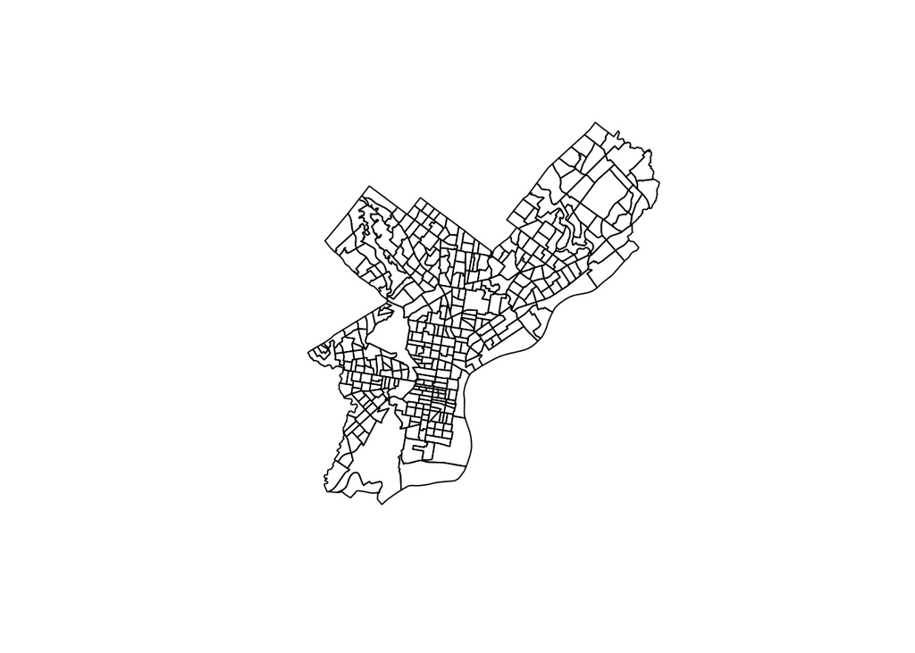

```r
# Plot the geometry of philly.tracts with the base plot function
plot(pt_geo)
```

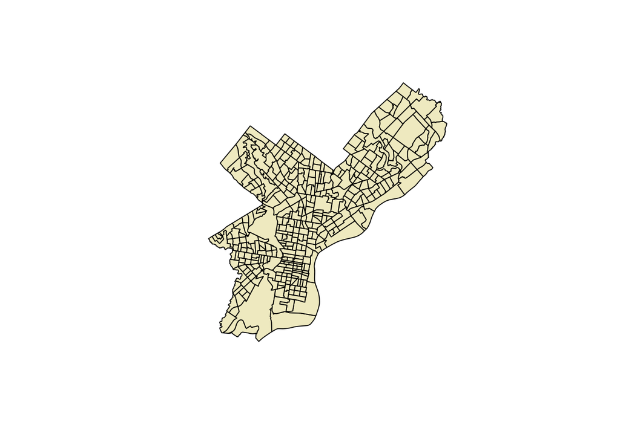

```r
# The base plot function has some aesthetic options we can use to tweak our plots
plot(pt_geo, col = "lemonchiffon2")
```

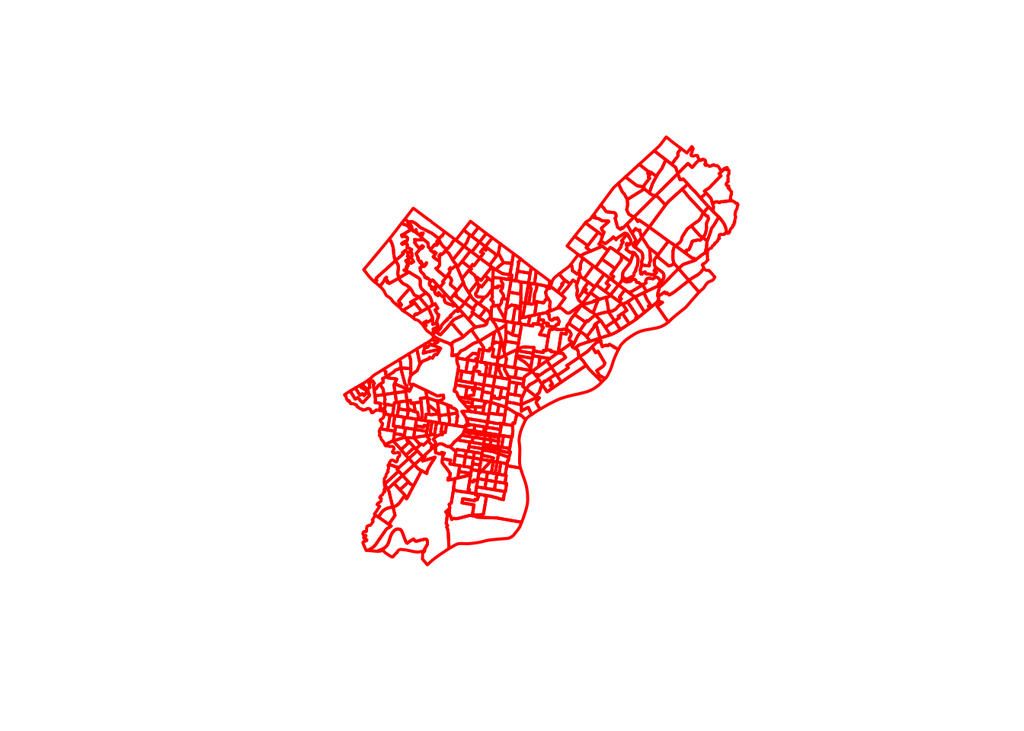

```r
plot(pt_geo, lwd = 2, border = "red")
```

### Line data

Next let’s look at an example of line data: streets in Philadelphia with bicycle access. This data was sourced directly from the [Philadelphia Bike Network](https://www.opendataphilly.org/dataset/bike-network).

```r
bn_sf <- st_read("data/Bike_Network/Bike_Network.shp")  # read shapefile as an sf object
class(bn_sf)  # bn.sf is an sf object, which is a subclass of data.frame
```

```
## [1] "sf"         "data.frame"
```

```r
# Once again, let's accss the spatial attributes of this sf object with the st_geometry command.
bn_geo <- st_geometry(bn_sf)
bn_geo[[1]]  # line segment 1
bn_geo[[2]]  # line segment 2
bn_sf[1:2,]
```

```
## Simple feature collection with 2 features and 8 fields
## Geometry type: LINESTRING
## Dimension:     XY
## Bounding box:  xmin: -75.26124 ymin: 39.87651 xmax: -75.25149 ymax: 39.88373
## Geodetic CRS:  WGS 84
##   OBJECTID SEG_ID   STREETNAME ST_CODE ONEWAY CLASS         TYPE Shape__Len
## 1        1 100002 BARTRAM  AVE   16120      B     2 Conventional   1116.637
## 2        2 100003 BARTRAM  AVE   16120      B     2 Conventional    371.888
##                         geometry
## 1 LINESTRING (-75.25362 39.88...
## 2 LINESTRING (-75.25149 39.88...
```

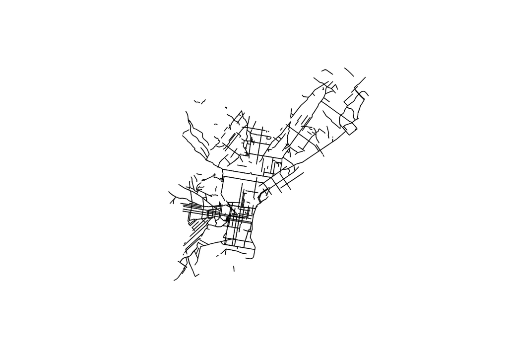

```r
# Let's plot the bike network data
plot(bn_geo)
```

### Point data

As an example of point data, we will work with crime incidents that occurred in Philadelphia in September 2018. The full publicly available crime incidents database for Philadelphia is maintained by the Philadelphia Police Department and is available on the [OpenDataPhilly](https://www.opendataphilly.org/dataset/crime-incidents) website.

```r
library(tidyverse)

crime <- readRDS("data/crime_incidents.rds")

# The crime data is an sf object of type POINT and includes information on the date, time and offense type for each incident
class(crime)
```

```
## [1] "sf"         "data.frame"
```

```r
head(crime)
```

```
## Simple feature collection with 6 features and 6 fields
## Geometry type: POINT
## Dimension:     XY
## Bounding box:  xmin: -75.24586 ymin: 39.91655 xmax: -75.08267 ymax: 40.0162
## Geodetic CRS:  WGS 84
##   longitude latitude         location_block dispatch_date dispatch_time
## 1 -75.23215 39.92315    6500 BLOCK GRAYS AV    2018-09-01      18:07:00
## 2 -75.23593 39.94403  5700 BLOCK ASHLAND AV    2018-09-02      02:43:00
## 3 -75.21525 39.94017 1300 BLOCK DIVINITY ST    2018-09-05      09:30:00
## 4 -75.24586 39.91655   2200 BLOCK ISLAND AV    2018-09-05      11:48:00
## 5 -75.22554 39.94184   1300 BLOCK S 54TH ST    2018-09-05      18:45:00
## 6 -75.08267 40.01620 1600 BLOCK MARGARET ST    2018-09-13      07:45:00
##                     offense_type                   geometry
## 1 Recovered Stolen Motor Vehicle POINT (-75.23215 39.92315)
## 2 Recovered Stolen Motor Vehicle POINT (-75.23593 39.94403)
## 3 Recovered Stolen Motor Vehicle POINT (-75.21525 39.94017)
## 4 Recovered Stolen Motor Vehicle POINT (-75.24586 39.91655)
## 5 Recovered Stolen Motor Vehicle POINT (-75.22554 39.94184)
## 6 Recovered Stolen Motor Vehicle  POINT (-75.08267 40.0162)
```

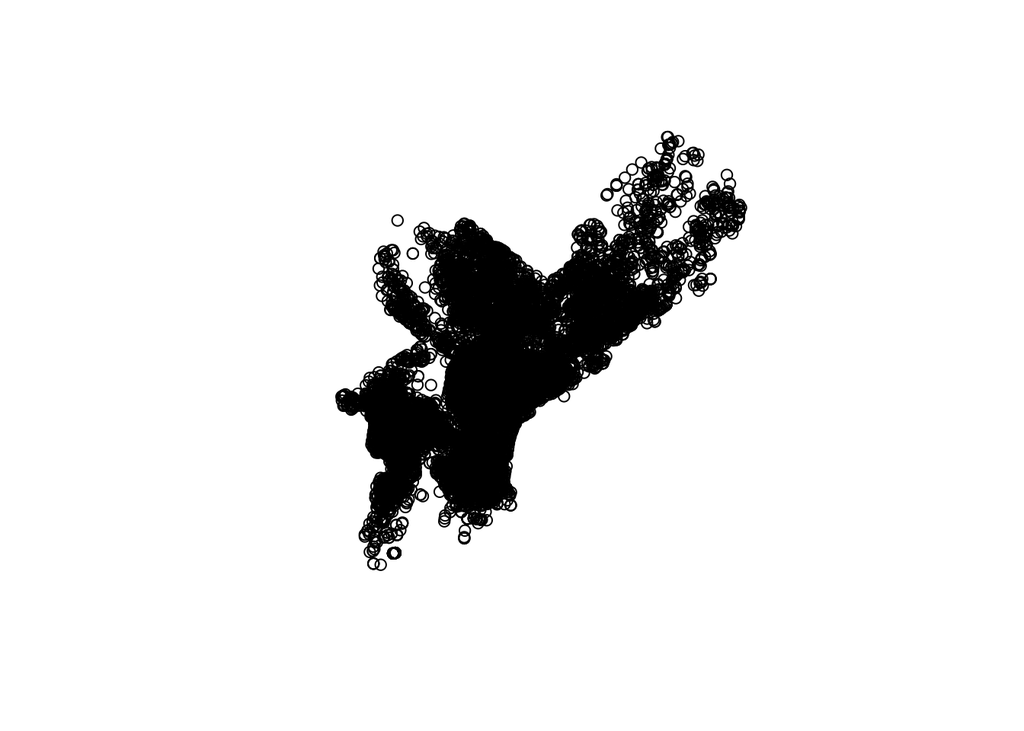

```r
plot(st_geometry(crime))
```

```r
# Let's take a look at offense types and use dplyr to filter by offense_type...
table(crime$offense_type)
```

```
##
##                                                      Aggravated Assault Firearm
##                                       0                                     191
##           Aggravated Assault No Firearm                      All Other Offenses
##                                     446                                    2229
##                                   Arson                Burglary Non-Residential
##                                      41                                     106
##                    Burglary Residential                      Disorderly Conduct
##                                     454                                      38
##             DRIVING UNDER THE INFLUENCE                            Embezzlement
##                                     262                                      24
##              Forgery and Counterfeiting                                   Fraud
##                                      18                                     990
##                     Gambling Violations                     Homicide - Criminal
##                                       0                                      27
##                    Homicide - Criminal              Homicide - Gross Negligence
##                                       3                                       0
##                 Homicide - Justifiable                    Liquor Law Violations
##                                       0                                      12
##                     Motor Vehicle Theft          Narcotic / Drug Law Violations
##                                     235                                     794
##    Offenses Against Family and Children                          Other Assaults
##                                      21                                    2066
## Other Sex Offenses (Not Commercialized)    Prostitution and Commercialized Vice
##                                      64                                      53
##                      Public Drunkenness                                    Rape
##                                       2                                      87
##               Receiving Stolen Property          Recovered Stolen Motor Vehicle
##                                       1                                     563
##                         Robbery Firearm                      Robbery No Firearm
##                                     190                                     230
##                      Theft from Vehicle                                  Thefts
##                                    1191                                    2066
##                      Vagrancy/Loitering             Vandalism/Criminal Mischief
##                                       1                                    1181
##                       Weapon Violations
##                                     181
```

```r
homicide <- filter(crime, offense_type == "Homicide - Criminal")
fraud <- filter(crime, offense_type == "Fraud")

# Note subsets of an sf object are also sf objects
class(homicide)
```

```
## [1] "sf"         "data.frame"
```

```r
class(fraud)
```

```
## [1] "sf"         "data.frame"
```

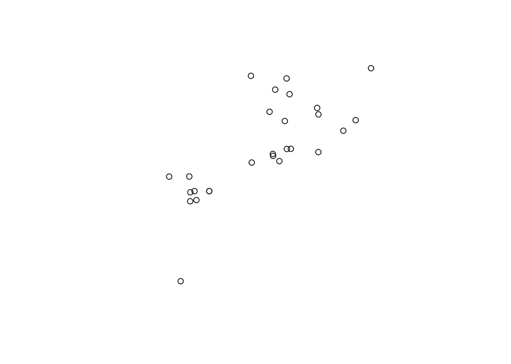

```r
# Plotting homicide and fraud incidents with the base plot function
plot(st_geometry(homicide))
```

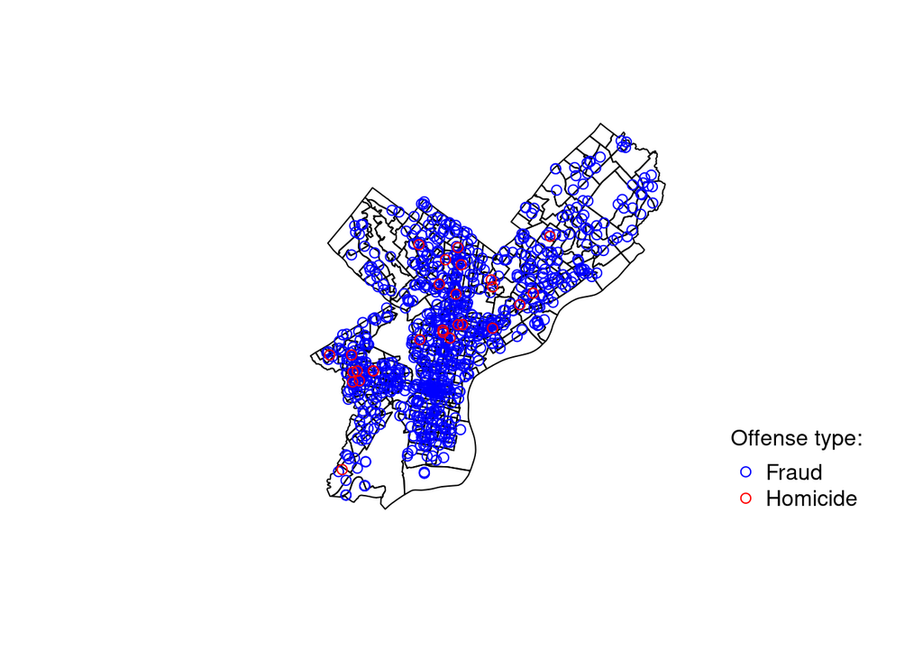

```r
# Points by themselves are not very easy to understand. Let's layer them on top of the tract polygons with add = TRUE
plot(pt_geo)
plot(st_geometry(fraud), col = "blue", alpha = 0.1, add = TRUE)
plot(st_geometry(homicide), col = "red", add = TRUE)
legend("bottomright", legend = c("Fraud", "Homicide"), title = "Offense type:", col = c("blue", "red"), pch = 1, bty = "n")
```

### Raster data

So far, we have considered point, line, and polygon data, all of which fall under the umbrella of vector data types. Rasters are a distinct GIS data type that we will consider only briefly because they cannot be handled with `sf` methods. We will look at the `volcano` dataset, which gives topographic information for Maunga Whau (a volcano located in Auckland, New Zealand) on a 10m by 10m grid. Because it is a relatively small raster, we can handle `volcano` using base functions. Larger rasters should be handled using the *raster* package.

```r
library(datasets)

# The volcano dataset is a 87x61 matrix
class(volcano)
```

```
## [1] "matrix" "array"
```

```r
str(volcano)
```

```
##  num [1:87, 1:61] 100 101 102 103 104 105 105 106 107 108 ...
```

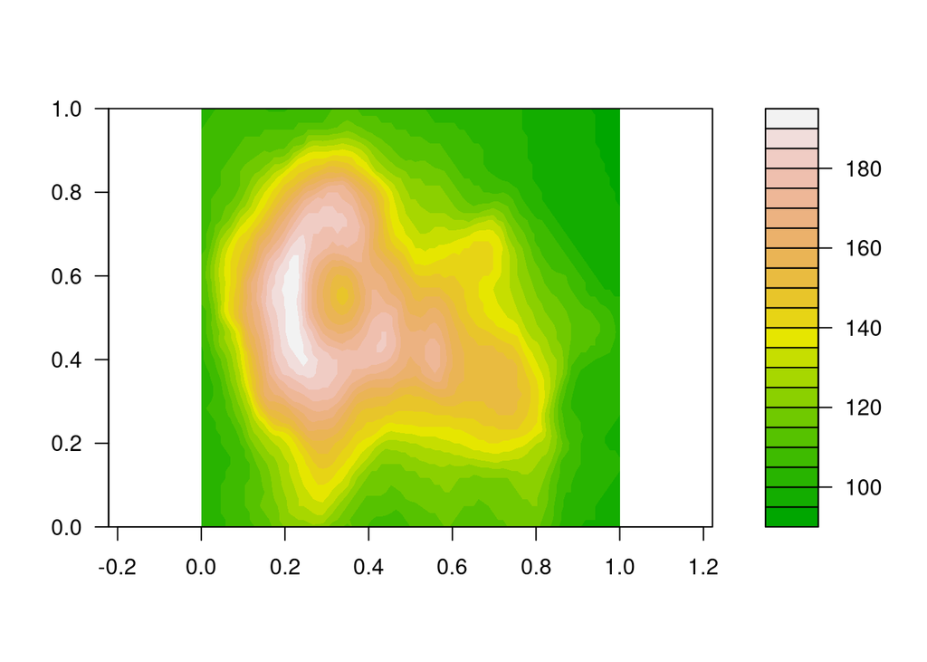

```r
filled.contour(volcano, color = terrain.colors, asp = 1)
```

## NYS Lyme incidence data

We will use the example of New York State county-aggregated Lyme disease incidence for 2014-2016 to try our hand at spatial analysis. This data is publicly available and can be accessed at the [Health Data NY](https://health.data.ny.gov/Health/Community-Health-Lyme-Disease-Incidence-Rate-per-1/6sxr-cqij) website. Raw data can be downloaded in .csv format. If you’re curious to see how this tabular data can be merged with a New York State county shapefile (available at [NYS GIS](https://gis.ny.gov/gisdata/inventories/details.cfm?DSID=927)), you can see how this is done in the ‘prep_nys_lyme_data.R’ script file located in the ‘data’ folder of our project directory. But for now, we’ll start with this data that has already been merged and converted to an ‘sf’ object.

```r
library(sf)

# Load NYS Lyme incidence data
lyme <- readRDS("data/nys_lyme_data.rds")

# Let's take a look at some data attributes
class(lyme)
```

```
## [1] "sf"         "data.frame"
```

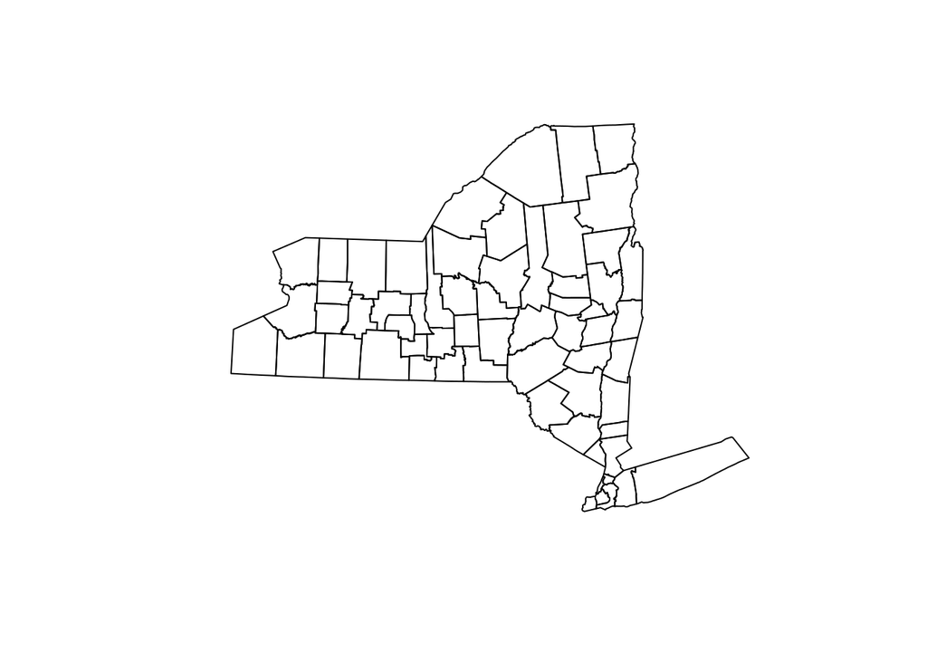

```r
#head(lyme)

# Note that the variable Lyme.Incidence.Rate gives the county-level Lyme disease incidence per 100,000 population

# Once again, we can plot the spatial attrbutes of this data
plot(st_geometry(lyme))
```

This data is an example of regional rate data. An easy way to map this data is using the ‘tmap’ library. Let’s load ‘tmap’ and create an interactive map with just a few lines of code.

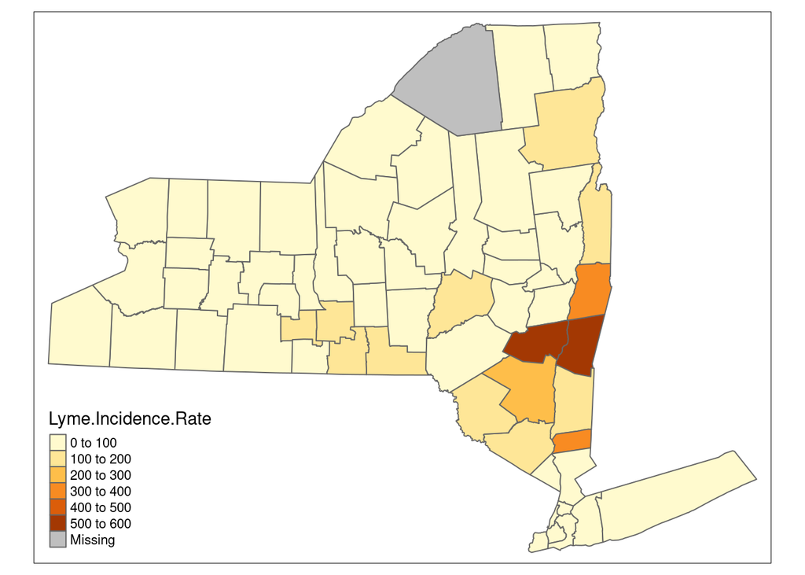

```r
library(tmap)

#tmap_mode("view")  # set mode to interactive
tm_shape(lyme) +    # specify sf object with geographic attribute of interest
  tm_polygons("Lyme.Incidence.Rate")  # specify column with value of interest
```

We have a missing value in St. Lawrence county. Let’s remove this row from the data so it doesn’t throw an error later in our analysis.

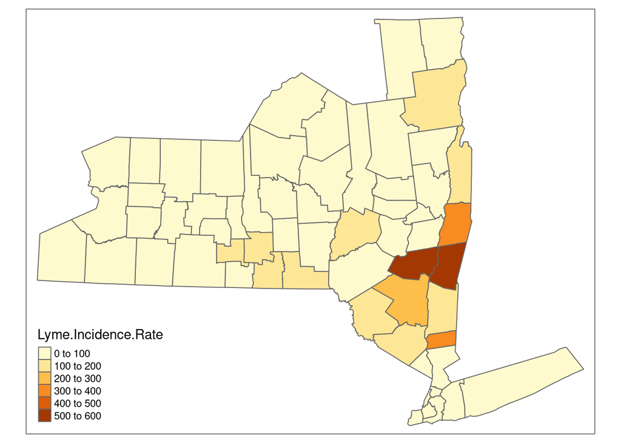

```r
lyme <- lyme[!is.na(lyme$Lyme.Incidence.Rate),]

# Let's map again
#tmap_mode("view")  # set mode to interactive
tm_shape(lyme) +    # specify sf object with geographic attribute of interest
  tm_polygons("Lyme.Incidence.Rate")  # specify column with value of interest
```

## Global clustering (Moran’s I)

This section was adapted from a tutorial created by Manuel Gimmond, which can be found on his [github page](https://mgimond.github.io/simple_moransI_example/).

### Assess data distribution

Let’s begin by looking at the distribution of our Lyme incidence rate data. The Moran’s *I* statistic is not robust to extreme values or outliers so we will need to transform our data if it deviates greatly from a normal distribution.

```r
# Five-number summary
summary(lyme$Lyme.Incidence.Rate)
```

```
##    Min. 1st Qu.  Median    Mean 3rd Qu.    Max.
##    1.90   13.50   36.30   80.27   98.50  599.60
```

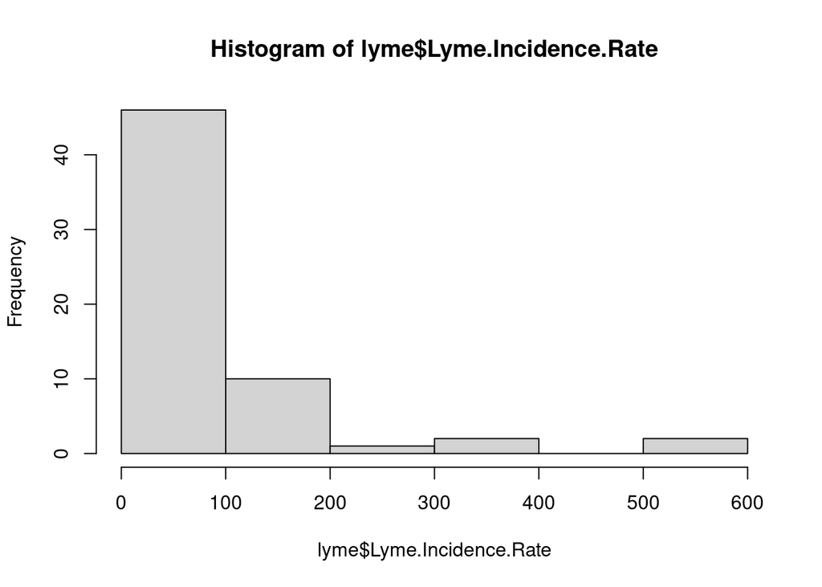

```r
# Histogram
hist(lyme$Lyme.Incidence.Rate)
```

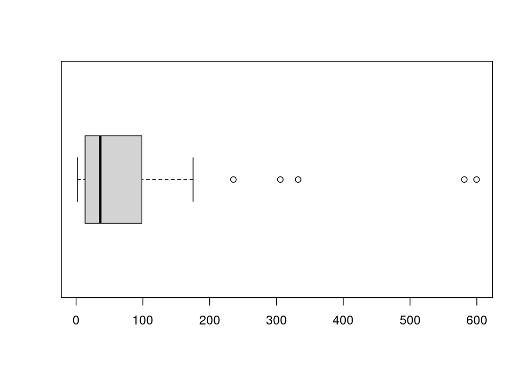

```r
# Boxplot
boxplot(lyme$Lyme.Incidence.Rate, horizontal = TRUE)
```

Our data is skewed strongly to the right with lots of outliers much greater than the mean. Let’s see if a log transformation can make our data look more normal.

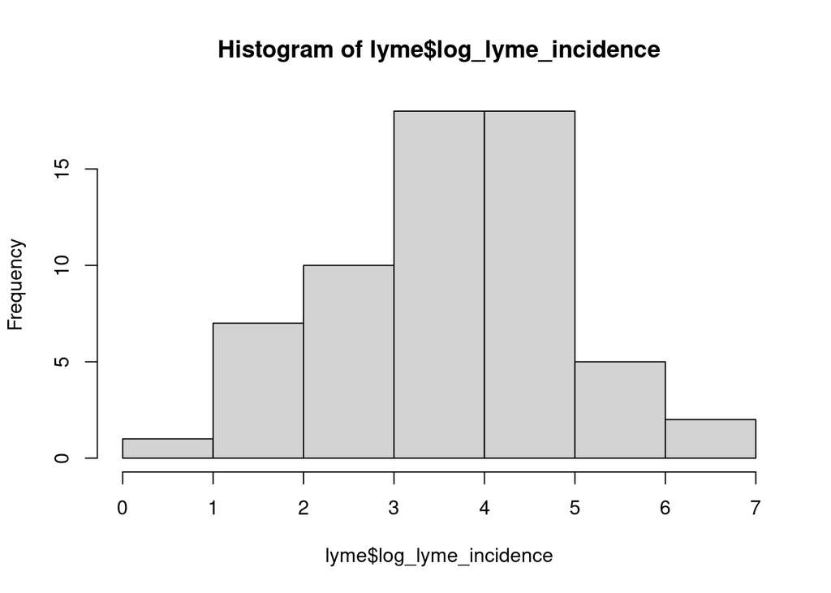

```r
# Create new variable that is the log-transformed incidence rate
lyme$log_lyme_incidence <- log(lyme$Lyme.Incidence.Rate)

# Histogram
hist(lyme$log_lyme_incidence)
```

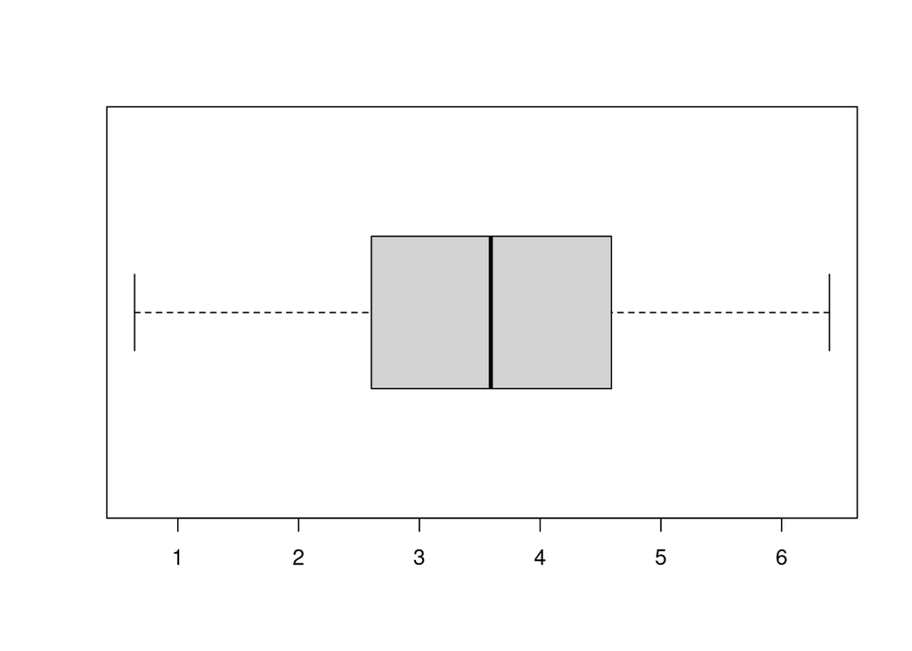

```r
# Boxplot
boxplot(lyme$log_lyme_incidence, horizontal = TRUE)
```

That’s much better! We can see what our log-transformed values look like on a map.

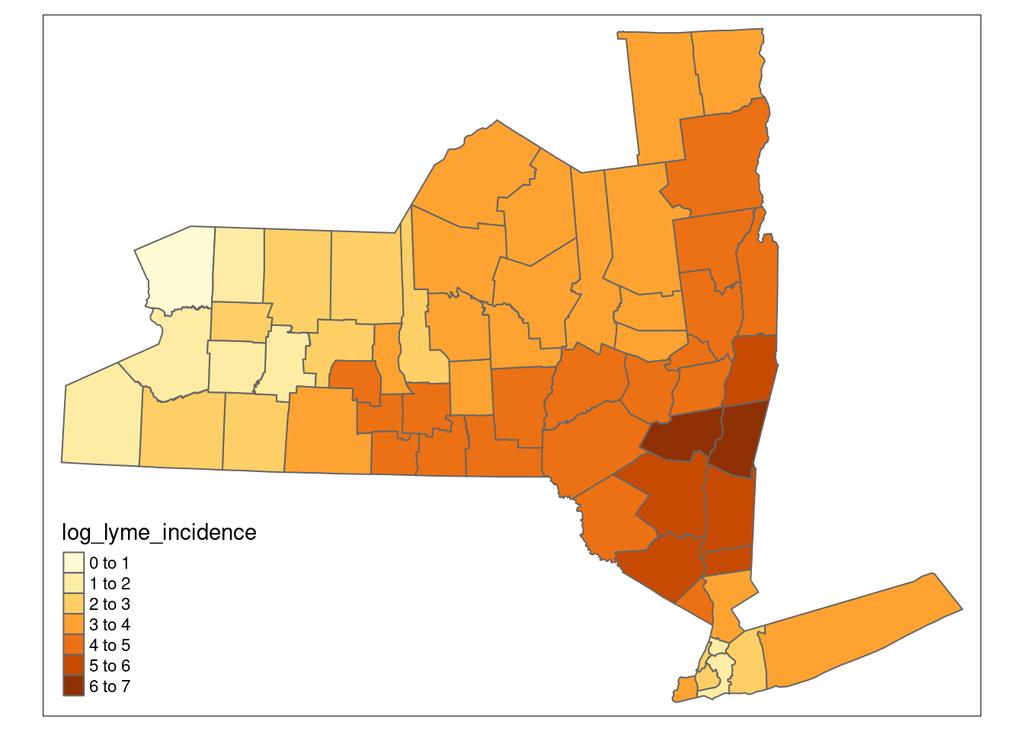

```r
tm_shape(lyme) +    # specify sf object with geographic attribute of interest
  tm_polygons("log_lyme_incidence")  # specify column with value of interest
```

### Define neighboring polygons

Now we’re ready to begin our analysis. The first step is to define “neighboring” polygons. Recall that neighbors can be defined based on contiguity or distance or as the *k* nearest neighbors to each polygon. We’ll use a **queen**-case contiguity-based definition, where any contiguous polygon that shares at least one vertex will be considered a neighbor. We can store the neighbors of each one of our polygons by creating an ‘nb’ object using the ‘poly2nb’ function from the ‘spdep’ library.

```r
library(spdep)

# Create nb object from Lyme dataset
lyme_nb <- poly2nb(lyme, queen = T) # queen case
class(lyme_nb)
```

```
## [1] "nb"
```

```r
#str(nb)

# View the neighbors of the first polygon
lyme_nb[[1]]
```

```
## [1] 11 20 42 45 46 47
```

```r
lyme$NAME[1]
```

```
## [1] "Albany"
```

```r
lyme$NAME[c(11, 20, 42, 45, 46, 47)]
```

```
## [1] "Columbia"    "Greene"      "Rensselaer"  "Saratoga"    "Schenectady"
## [6] "Schoharie"
```

### Assign weights to neighbors

Next, we’ll assign weights to each neighboring polygon. We’ll use the simplest option (’style=“W”), which assigns equal weight to each neighboring polygon. In other words, the weight applied to the neigbors of a polygon will equal 1/(no. of neighbors for that polygon).

```r
# Calculate weights from nb object, we'll specify style = "W" for equal weights
lyme_weights <- nb2listw(lyme_nb, style = "W")
class(lyme_weights)
```

```
## [1] "listw" "nb"
```

```r
# View the weight of the first polygon's neighbors
str(lyme_weights, max.level = 1) # view the structure of lw, we'll set max.level = 1 for easier viewing
```

```
## List of 3
##  $ style     : chr "W"
##  $ neighbours:List of 61
##   ..- attr(*, "class")= chr "nb"
##   ..- attr(*, "region.id")= chr [1:61] "1" "2" "3" "4" ...
##   ..- attr(*, "call")= language poly2nb(pl = lyme, queen = T)
##   ..- attr(*, "type")= chr "queen"
##   ..- attr(*, "sym")= logi TRUE
##  $ weights   :List of 61
##   ..- attr(*, "mode")= chr "binary"
##   ..- attr(*, "W")= logi TRUE
##   ..- attr(*, "comp")=List of 1
##  - attr(*, "class")= chr [1:2] "listw" "nb"
##  - attr(*, "region.id")= chr [1:61] "1" "2" "3" "4" ...
##  - attr(*, "call")= language nb2listw(neighbours = lyme_nb, style = "W")
```

```r
lyme_weights$weights[[1]]  # The weights of the neighbors for the first polygon (Albany)
```

```
## [1] 0.1666667 0.1666667 0.1666667 0.1666667 0.1666667 0.1666667
```

```r
                 # Recall that Albany has 6 neighbors

lyme$NAME[2]     # Allegheny
```

```
## [1] "Allegany"
```

```r
lyme_nb[[2]]          # Allegheny has 4 neighbors
```

```
## [1]  5 26 50 60
```

```r
lyme_weights$weights[[2]]  # The weights of the neighbors for Allegheny
```

```
## [1] 0.25 0.25 0.25 0.25
```

### Perform hypothesis testing

Now we can calculate the Moran’s *I* statistic and perform hypothesis testing using ‘moran.test’ (analytical calculation) and ‘moran.mc’ (via Monte Carlo simulations). These functions require that we specify the variable of interest and the list of neighbor weights for each polygon. The option ‘alternative = “greater”’ specifies testing for *positive* spatial autocorrelation, which is also the default for these functions. The ‘moran.mc’ function also requires that we specify the number of simulations with option ‘nsim’.

```r
# Analytical test - quicker computation but sensitive to irregularly distributed polygons
moran.test(lyme$log_lyme_incidence, lyme_weights, alternative = "greater")
```

```
##
##  Moran I test under randomisation
##
## data:  lyme$log_lyme_incidence
## weights: lyme_weights
##
## Moran I statistic standard deviate = 8.7379, p-value < 2.2e-16
## alternative hypothesis: greater
## sample estimates:
## Moran I statistic       Expectation          Variance
##       0.720555645      -0.016666667       0.007118479
```

```r
# Monte Carlo (MC) simulation is slower but the preferred  method to calculate an accurate p-value
MC <- moran.mc(lyme$log_lyme_incidence, lyme_weights, nsim = 999, alternative = "greater")
MC
```

```
##
##  Monte-Carlo simulation of Moran I
##
## data:  lyme$log_lyme_incidence
## weights: lyme_weights
## number of simulations + 1: 1000
##
## statistic = 0.72056, observed rank = 1000, p-value = 0.001
## alternative hypothesis: greater
```

We can see the results of the MC simulations graphically by passing the output of MC model to the ‘plot’ function.

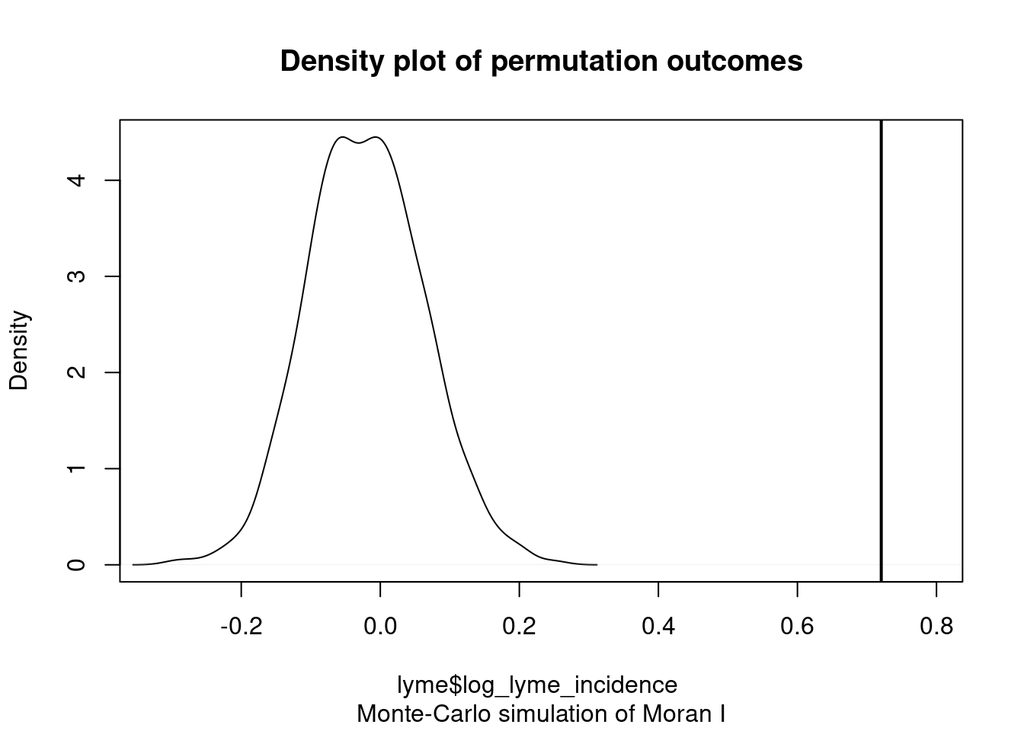

```r
plot(MC)
```

## Local clustering (local Moran)

The local Moran statistic is an extension of the Moran’s *I* for the analysis of *local* (rather than global) spatial autocorrelation. There are some steps in common with the global clustering analysis we performed previously (for example, we have to calculate neighbor weights again) but there are key differences, due to particularities of the ‘rgeoda’ library.

### Assign neighbor weights

We will once again find queen-case contiguous weights, though in ‘rgeoda’ we do this with the ‘queen_weights’ function. Note instead of a list of weights like we saw previously with the ‘nb2listw’ function, ‘queen_weights’ outputs an ‘rgeoda’ ‘Weight’ object, which has some nice features.

```r
library(rgeoda)

# Find queen-case contiguous weights
lyme_gweights <- queen_weights(lyme)
class(lyme_gweights)
```

```
## [1] "Weight"
## attr(,"package")
## [1] "rgeoda"
```

```r
# str function allows us to see a nice summary of the weights object
str(lyme_gweights)
```

```
## Reference class 'Weight' [package "rgeoda"] with 9 fields
##  $ gda_w           :Formal class 'p_GeoDaWeight' [package "rgeoda"] with 1 slot
##   .. ..@ pointer:<externalptr>
##  $ is_symmetric    : logi TRUE
##  $ sparsity        : num 0.0763
##  $ min_neighbors   : int 1
##  $ max_neighbors   : int 8
##  $ num_obs         : int 61
##  $ mean_neighbors  : num 4.66
##  $ median_neighbors: num 5
##  $ has_isolates    : logi FALSE
##  and 27 methods, of which 13 are  possibly relevant:
##    GetNeighbors, GetNeighborSize, GetNeighborWeights, GetPointer, GetSparsity,
##    HasIsolates, initialize, IsSymmetric, SaveToFile, SetNeighbors,
##    SetNeighborsAndWeights, SpatialLag, Update
```

```r
# See the neighbors of the first polygon (Albany)
get_neighbors(lyme_gweights, 1)
```

```
## [1] 11 20 42 45 46 47
```

```r
lyme$NAME[1]
```

```
## [1] "Albany"
```

```r
lyme$NAME[get_neighbors(lyme_gweights, 1)]
```

```
## [1] "Columbia"    "Greene"      "Rensselaer"  "Saratoga"    "Schenectady"
## [6] "Schoharie"
```

```r
# See the neighbors of the first polygon (Allegany)
get_neighbors(lyme_gweights, 2)
```

```
## [1]  5 26 50 60
```

```r
lyme$NAME[2]
```

```
## [1] "Allegany"
```

```r
lyme$NAME[get_neighbors(lyme_gweights, 2)]
```

```
## [1] "Cattaraugus" "Livingston"  "Steuben"     "Wyoming"
```

```r
# See the neighbor weights of the first and second polygons
get_neighbors_weights(lyme_gweights, 1)
```

```
## [1] 1 1 1 1 1 1
```

```r
get_neighbors_weights(lyme_gweights, 2)
```

```
## [1] 1 1 1 1
```

### Calculate Local Moran statistic

Now you can use your ‘geoda’ ‘Weights’ to calculate the Local Moran statistic at each polygon.

```r
# We will coerce our data variable into a one-column data frame because this is the format required by the local_moran function
log_lyme_df <- as.data.frame(lyme$log_lyme_incidence)

# Now we can run the local_moran function
lyme_lisa <- local_moran(lyme_gweights, log_lyme_df)

# local_moran returns a LISA object
class(lyme_lisa)
```

```
## [1] "LISA"
## attr(,"package")
## [1] "rgeoda"
```

Finally, we can make a map of our results! ‘rgeoda’ includes some nifty functions (‘map_colors’, ‘map_labels’ and ‘map_clusters’ to help us with our mapping).

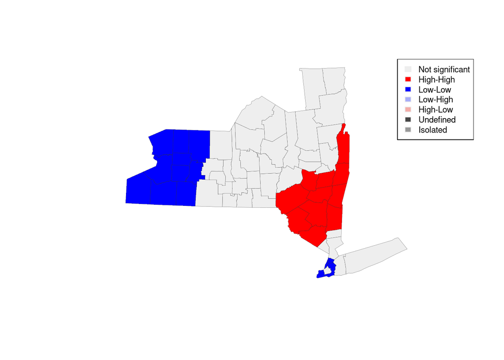

```r
map_colors <- lisa_colors(lyme_lisa)
map_labels <- lisa_labels(lyme_lisa)
map_clusters <- lisa_clusters(lyme_lisa)

plot(st_geometry(lyme),
     col=sapply(map_clusters, function(x){return(map_colors[[x+1]])}),
     border = "#333333", lwd=0.2)
legend('topright', legend = map_labels, fill = map_colors, border = "#eeeeee", cex = 0.7)
```